# sample super store

As a business manager, try to find out the weak areas where you can work to make more profit.

```python
import pandas as pd
import numpy as np
import matplotlib.pyplot as plt
import seaborn as sns
```

```python
data=pd.read_csv('C:\\Users\\SKR\\Downloads\\SampleSuperstore.csv')
data
```

|  | Ship Mode | Segment | Country | City | State | Postal Code | Region | Category | Sub-Category | Sales | Quantity | Discount | Profit |
| --- | --- | --- | --- | --- | --- | --- | --- | --- | --- | --- | --- | --- | --- |
| 0 | Second Class | Consumer | United States | Henderson | Kentucky | 42420 | South | Furniture | Bookcases | 261.9600 | 2 | 0.00 | 41.9136 |
| 1 | Second Class | Consumer | United States | Henderson | Kentucky | 42420 | South | Furniture | Chairs | 731.9400 | 3 | 0.00 | 219.5820 |
| 2 | Second Class | Corporate | United States | Los Angeles | California | 90036 | West | Office Supplies | Labels | 14.6200 | 2 | 0.00 | 6.8714 |
| 3 | Standard Class | Consumer | United States | Fort Lauderdale | Florida | 33311 | South | Furniture | Tables | 957.5775 | 5 | 0.45 | -383.0310 |
| 4 | Standard Class | Consumer | United States | Fort Lauderdale | Florida | 33311 | South | Office Supplies | Storage | 22.3680 | 2 | 0.20 | 2.5164 |
| ... | ... | ... | ... | ... | ... | ... | ... | ... | ... | ... | ... | ... | ... |
| 9989 | Second Class | Consumer | United States | Miami | Florida | 33180 | South | Furniture | Furnishings | 25.2480 | 3 | 0.20 | 4.1028 |
| 9990 | Standard Class | Consumer | United States | Costa Mesa | California | 92627 | West | Furniture | Furnishings | 91.9600 | 2 | 0.00 | 15.6332 |
| 9991 | Standard Class | Consumer | United States | Costa Mesa | California | 92627 | West | Technology | Phones | 258.5760 | 2 | 0.20 | 19.3932 |
| 9992 | Standard Class | Consumer | United States | Costa Mesa | California | 92627 | West | Office Supplies | Paper | 29.6000 | 4 | 0.00 | 13.3200 |
| 9993 | Second Class | Consumer | United States | Westminster | California | 92683 | West | Office Supplies | Appliances | 243.1600 | 2 | 0.00 | 72.9480 |

9994 rows × 13 columns

```python
data.head() # it will get 1st five values of a dataset
```

|  | Ship Mode | Segment | Country | City | State | Postal Code | Region | Category | Sub-Category | Sales | Quantity | Discount | Profit |
| --- | --- | --- | --- | --- | --- | --- | --- | --- | --- | --- | --- | --- | --- |
| 0 | Second Class | Consumer | United States | Henderson | Kentucky | 42420 | South | Furniture | Bookcases | 261.9600 | 2 | 0.00 | 41.9136 |
| 1 | Second Class | Consumer | United States | Henderson | Kentucky | 42420 | South | Furniture | Chairs | 731.9400 | 3 | 0.00 | 219.5820 |
| 2 | Second Class | Corporate | United States | Los Angeles | California | 90036 | West | Office Supplies | Labels | 14.6200 | 2 | 0.00 | 6.8714 |
| 3 | Standard Class | Consumer | United States | Fort Lauderdale | Florida | 33311 | South | Furniture | Tables | 957.5775 | 5 | 0.45 | -383.0310 |
| 4 | Standard Class | Consumer | United States | Fort Lauderdale | Florida | 33311 | South | Office Supplies | Storage | 22.3680 | 2 | 0.20 | 2.5164 |

```python
data.tail() #it will get last five values of a dataset
```

|  | Ship Mode | Segment | Country | City | State | Postal Code | Region | Category | Sub-Category | Sales | Quantity | Discount | Profit |
| --- | --- | --- | --- | --- | --- | --- | --- | --- | --- | --- | --- | --- | --- |
| 9989 | Second Class | Consumer | United States | Miami | Florida | 33180 | South | Furniture | Furnishings | 25.248 | 3 | 0.2 | 4.1028 |
| 9990 | Standard Class | Consumer | United States | Costa Mesa | California | 92627 | West | Furniture | Furnishings | 91.960 | 2 | 0.0 | 15.6332 |
| 9991 | Standard Class | Consumer | United States | Costa Mesa | California | 92627 | West | Technology | Phones | 258.576 | 2 | 0.2 | 19.3932 |
| 9992 | Standard Class | Consumer | United States | Costa Mesa | California | 92627 | West | Office Supplies | Paper | 29.600 | 4 | 0.0 | 13.3200 |
| 9993 | Second Class | Consumer | United States | Westminster | California | 92683 | West | Office Supplies | Appliances | 243.160 | 2 | 0.0 | 72.9480 |

```python
data.sample() #it will get single default  value  from a dataset
```

|  | Ship Mode | Segment | Country | City | State | Postal Code | Region | Category | Sub-Category | Sales | Quantity | Discount | Profit |
| --- | --- | --- | --- | --- | --- | --- | --- | --- | --- | --- | --- | --- | --- |
| 5210 | Standard Class | Corporate | United States | Newark | Delaware | 19711 | East | Office Supplies | Storage | 465.18 | 3 | 0.0 | 120.9468 |

```python
data.columns # we will get all the columns
```

```
Index(['Ship Mode', 'Segment', 'Country', 'City', 'State', 'Postal Code',
       'Region', 'Category', 'Sub-Category', 'Sales', 'Quantity', 'Discount',
       'Profit'],
      dtype='object')
```

```python
data.shape # for finding the size
```

```
(9994, 13)
```

```python
data.isnull() # for finding the null values
```

|  | Ship Mode | Segment | Country | City | State | Postal Code | Region | Category | Sub-Category | Sales | Quantity | Discount | Profit |
| --- | --- | --- | --- | --- | --- | --- | --- | --- | --- | --- | --- | --- | --- |
| 0 | False | False | False | False | False | False | False | False | False | False | False | False | False |
| 1 | False | False | False | False | False | False | False | False | False | False | False | False | False |
| 2 | False | False | False | False | False | False | False | False | False | False | False | False | False |
| 3 | False | False | False | False | False | False | False | False | False | False | False | False | False |
| 4 | False | False | False | False | False | False | False | False | False | False | False | False | False |
| ... | ... | ... | ... | ... | ... | ... | ... | ... | ... | ... | ... | ... | ... |
| 9989 | False | False | False | False | False | False | False | False | False | False | False | False | False |
| 9990 | False | False | False | False | False | False | False | False | False | False | False | False | False |
| 9991 | False | False | False | False | False | False | False | False | False | False | False | False | False |
| 9992 | False | False | False | False | False | False | False | False | False | False | False | False | False |
| 9993 | False | False | False | False | False | False | False | False | False | False | False | False | False |

9994 rows × 13 columns

```python
data.isnull().any()
```

```
Ship Mode       False
Segment         False
Country         False
City            False
State           False
Postal Code     False
Region          False
Category        False
Sub-Category    False
Sales           False
Quantity        False
Discount        False
Profit          False
dtype: bool
```

```python
data.isnull().sum() # Missing values checking
```

```
Ship Mode       0
Segment         0
Country         0
City            0
State           0
Postal Code     0
Region          0
Category        0
Sub-Category    0
Sales           0
Quantity        0
Discount        0
Profit          0
dtype: int64
```

#### Count:Count number of non-NA/null observations.

#### Max:Maximum of the values in the object.

#### Min:Minimum of the values in the object

#### Mean:Mean of the values.

#### std:Standard deviation of the observations.

```python
data.describe() #check the data description
```

|  | Postal Code | Sales | Quantity | Discount | Profit |
| --- | --- | --- | --- | --- | --- |
| count | 9994.000000 | 9994.000000 | 9994.000000 | 9994.000000 | 9994.000000 |
| mean | 55190.379428 | 229.858001 | 3.789574 | 0.156203 | 28.656896 |
| std | 32063.693350 | 623.245101 | 2.225110 | 0.206452 | 234.260108 |
| min | 1040.000000 | 0.444000 | 1.000000 | 0.000000 | -6599.978000 |
| 25% | 23223.000000 | 17.280000 | 2.000000 | 0.000000 | 1.728750 |
| 50% | 56430.500000 | 54.490000 | 3.000000 | 0.200000 | 8.666500 |
| 75% | 90008.000000 | 209.940000 | 5.000000 | 0.200000 | 29.364000 |
| max | 99301.000000 | 22638.480000 | 14.000000 | 0.800000 | 8399.976000 |

```python
data.nunique() #find the number of unique values
```

```
Ship Mode          4
Segment            3
Country            1
City             531
State             49
Postal Code      631
Region             4
Category           3
Sub-Category      17
Sales           5825
Quantity          14
Discount          12
Profit          7287
dtype: int64
```

```python
data.dtypes  #Check the structure of dataset
```

```
Ship Mode        object
Segment          object
Country          object
City             object
State            object
Postal Code       int64
Region           object
Category         object
Sub-Category     object
Sales           float64
Quantity          int64
Discount        float64
Profit          float64
dtype: object
```

```python
data.corr()
```

|  | Postal Code | Sales | Quantity | Discount | Profit |
| --- | --- | --- | --- | --- | --- |
| Postal Code | 1.000000 | -0.023854 | 0.012761 | 0.058443 | -0.029961 |
| Sales | -0.023854 | 1.000000 | 0.200795 | -0.028190 | 0.479064 |
| Quantity | 0.012761 | 0.200795 | 1.000000 | 0.008623 | 0.066253 |
| Discount | 0.058443 | -0.028190 | 0.008623 | 1.000000 | -0.219487 |
| Profit | -0.029961 | 0.479064 | 0.066253 | -0.219487 | 1.000000 |

## Exploratory Data Analysis(EDA)

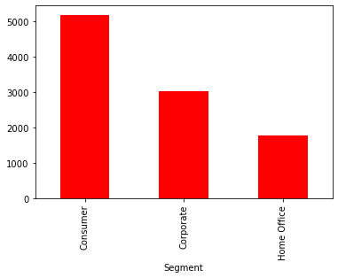

```python
data.groupby('Segment')['Segment'].agg('count').plot.bar(color='Red');
```

## Data Visualization:

We are using Seaborn library for Data visualization. Seaborn is a library for making attractive and informative statistical graphics in Python. we use numpy and pandas data structures.All kinds of features and the relationship within features we will descuss with the visualization

## Histograms for Continuous Features

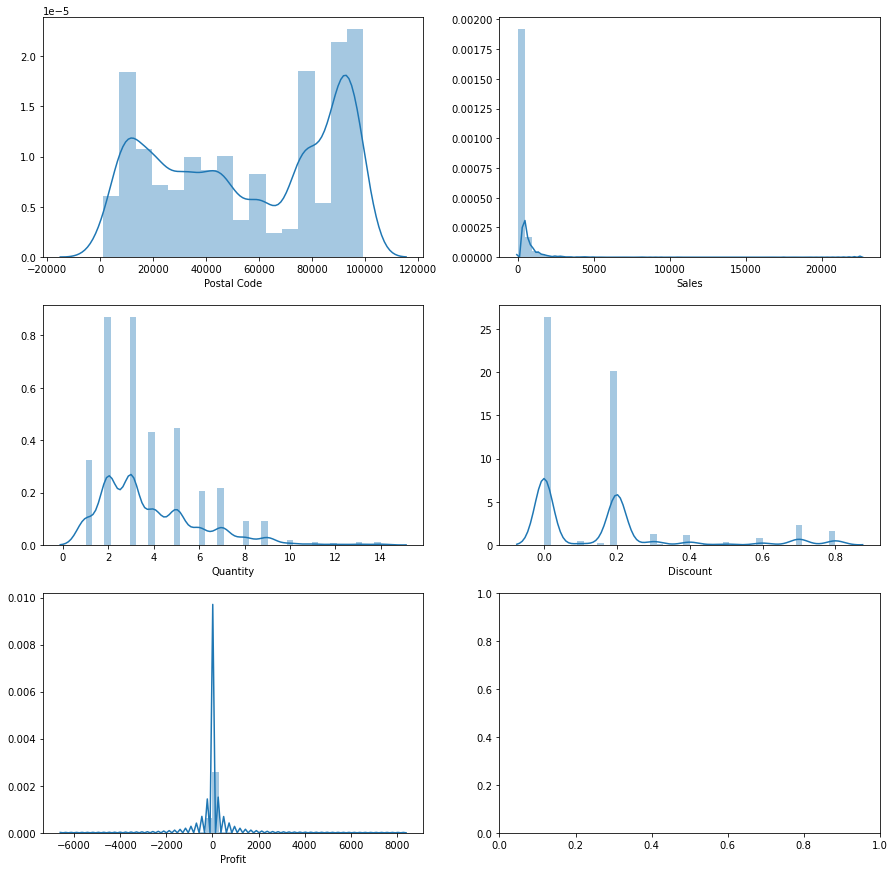

```python
#Display Multiple Distribution Plots. Histograms for Continuous Features
fig,ax = plt.subplots(3,2, figsize=(15,15))  # 'ax' has references to all the four axes
#sns.distplot(data['Ship Mode'], ax = ax[0,0])
#sns.distplot(data['Segment'], ax = ax[0,1])
#sns.distplot(data['Country'], ax = ax[0,2])
#sns.distplot(data['City'], ax = ax[0,3])
#sns.distplot(data['State'], ax = ax[1,0])
sns.distplot(data['Postal Code'], ax = ax[0,0])
#sns.distplot(data['Region'], ax = ax[1,2])
#sns.distplot(data['Category'], ax = ax[1,3])
#sns.distplot(data['Sub-Category'], ax = ax[2,0])
sns.distplot(data['Sales'], ax = ax[0,1])
sns.distplot(data['Quantity'], ax = ax[1,0])
sns.distplot(data['Discount'], ax = ax[1,1])
sns.distplot(data['Profit'], ax = ax[2,0])

plt.show()
```

From the above plot, we can able to get a rough idea of the sales from this dataset. For example, what is the average sales and profit

#### Now i am going to draw box plot of continues features w.r.t Segment

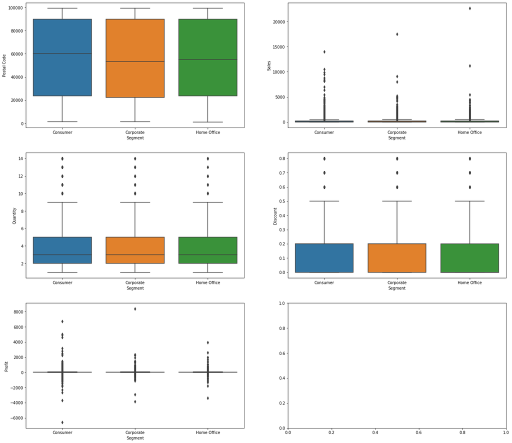

```python
fig,ax = plt.subplots(3,2, figsize=(22,20))     # 'ax' has references to all the four axes
#sns.boxplot(data['Segment'], data['Ship Mode'], ax = ax[0,0])  # Plot on 1st axes
#sns.boxplot(data['Segment'], data['Country'], ax = ax[0,1])  # Plot on IInd axes
#sns.boxplot(data['Segment'], data['City'], ax = ax[0,2])
#sns.boxplot(data['Segment'], data['State'], ax = ax[0,3])
sns.boxplot(data['Segment'], data['Postal Code'], ax = ax[0,0])
#sns.boxplot(data['Segment'], data['Region'], ax = ax[1,1])
#sns.boxplot(data['Segment'], data['Category'], ax = ax[1,2])
#sns.boxplot(data['Segment'], data['Sub-Category'], ax = ax[1,3])
sns.boxplot(data['Segment'], data['Sales'], ax = ax[0,1])
sns.boxplot(data['Segment'], data['Quantity'], ax = ax[1,0])
sns.boxplot(data['Segment'], data['Discount'], ax = ax[1,1])
sns.boxplot(data['Segment'], data['Profit'], ax = ax[2,0])
plt.show()
```

We can see from these plots that the average price of the store and and from this we have to find the Normalization.For some other features such as “Sales”,“Discount”,“profit”,"Quality" and they all shows that the prices in the store .

## convert categorical value into numerical value by using dummies

```python
data=pd.get_dummies(data)
data.head()
```

|  | Postal Code | Sales | Quantity | Discount | Profit | Ship Mode_First Class | Ship Mode_Same Day | Ship Mode_Second Class | Ship Mode_Standard Class | Segment_Consumer | ... | Sub-Category_Envelopes | Sub-Category_Fasteners | Sub-Category_Furnishings | Sub-Category_Labels | Sub-Category_Machines | Sub-Category_Paper | Sub-Category_Phones | Sub-Category_Storage | Sub-Category_Supplies | Sub-Category_Tables |
| --- | --- | --- | --- | --- | --- | --- | --- | --- | --- | --- | --- | --- | --- | --- | --- | --- | --- | --- | --- | --- | --- |
| 0 | 42420 | 261.9600 | 2 | 0.00 | 41.9136 | 0 | 0 | 1 | 0 | 1 | ... | 0 | 0 | 0 | 0 | 0 | 0 | 0 | 0 | 0 | 0 |
| 1 | 42420 | 731.9400 | 3 | 0.00 | 219.5820 | 0 | 0 | 1 | 0 | 1 | ... | 0 | 0 | 0 | 0 | 0 | 0 | 0 | 0 | 0 | 0 |
| 2 | 90036 | 14.6200 | 2 | 0.00 | 6.8714 | 0 | 0 | 1 | 0 | 0 | ... | 0 | 0 | 0 | 1 | 0 | 0 | 0 | 0 | 0 | 0 |
| 3 | 33311 | 957.5775 | 5 | 0.45 | -383.0310 | 0 | 0 | 0 | 1 | 1 | ... | 0 | 0 | 0 | 0 | 0 | 0 | 0 | 0 | 0 | 1 |
| 4 | 33311 | 22.3680 | 2 | 0.20 | 2.5164 | 0 | 0 | 0 | 1 | 1 | ... | 0 | 0 | 0 | 0 | 0 | 0 | 0 | 1 | 0 | 0 |

5 rows × 617 columns

```python
data['Profit'].mean()
```

```
28.656896307784802
```

```python
data.describe()
```

|  | Postal Code | Sales | Quantity | Discount | Profit | Ship Mode_First Class | Ship Mode_Same Day | Ship Mode_Second Class | Ship Mode_Standard Class | Segment_Consumer | ... | Sub-Category_Envelopes | Sub-Category_Fasteners | Sub-Category_Furnishings | Sub-Category_Labels | Sub-Category_Machines | Sub-Category_Paper | Sub-Category_Phones | Sub-Category_Storage | Sub-Category_Supplies | Sub-Category_Tables |
| --- | --- | --- | --- | --- | --- | --- | --- | --- | --- | --- | --- | --- | --- | --- | --- | --- | --- | --- | --- | --- | --- |
| count | 9994.000000 | 9994.000000 | 9994.000000 | 9994.000000 | 9994.000000 | 9994.000000 | 9994.000000 | 9994.000000 | 9994.000000 | 9994.000000 | ... | 9994.000000 | 9994.000000 | 9994.000000 | 9994.000000 | 9994.000000 | 9994.000000 | 9994.000000 | 9994.000000 | 9994.000000 | 9994.000000 |
| mean | 55190.379428 | 229.858001 | 3.789574 | 0.156203 | 28.656896 | 0.153892 | 0.054333 | 0.194617 | 0.597158 | 0.519412 | ... | 0.025415 | 0.021713 | 0.095757 | 0.036422 | 0.011507 | 0.137082 | 0.088953 | 0.084651 | 0.019011 | 0.031919 |
| std | 32063.693350 | 623.245101 | 2.225110 | 0.206452 | 234.260108 | 0.360864 | 0.226684 | 0.395925 | 0.490494 | 0.499648 | ... | 0.157391 | 0.145752 | 0.294273 | 0.187347 | 0.106657 | 0.343951 | 0.284691 | 0.278375 | 0.136572 | 0.175794 |
| min | 1040.000000 | 0.444000 | 1.000000 | 0.000000 | -6599.978000 | 0.000000 | 0.000000 | 0.000000 | 0.000000 | 0.000000 | ... | 0.000000 | 0.000000 | 0.000000 | 0.000000 | 0.000000 | 0.000000 | 0.000000 | 0.000000 | 0.000000 | 0.000000 |
| 25% | 23223.000000 | 17.280000 | 2.000000 | 0.000000 | 1.728750 | 0.000000 | 0.000000 | 0.000000 | 0.000000 | 0.000000 | ... | 0.000000 | 0.000000 | 0.000000 | 0.000000 | 0.000000 | 0.000000 | 0.000000 | 0.000000 | 0.000000 | 0.000000 |
| 50% | 56430.500000 | 54.490000 | 3.000000 | 0.200000 | 8.666500 | 0.000000 | 0.000000 | 0.000000 | 1.000000 | 1.000000 | ... | 0.000000 | 0.000000 | 0.000000 | 0.000000 | 0.000000 | 0.000000 | 0.000000 | 0.000000 | 0.000000 | 0.000000 |
| 75% | 90008.000000 | 209.940000 | 5.000000 | 0.200000 | 29.364000 | 0.000000 | 0.000000 | 0.000000 | 1.000000 | 1.000000 | ... | 0.000000 | 0.000000 | 0.000000 | 0.000000 | 0.000000 | 0.000000 | 0.000000 | 0.000000 | 0.000000 | 0.000000 |
| max | 99301.000000 | 22638.480000 | 14.000000 | 0.800000 | 8399.976000 | 1.000000 | 1.000000 | 1.000000 | 1.000000 | 1.000000 | ... | 1.000000 | 1.000000 | 1.000000 | 1.000000 | 1.000000 | 1.000000 | 1.000000 | 1.000000 | 1.000000 | 1.000000 |

8 rows × 617 columns

```python
# Calculating the correlation between Profit and Sales
data['Profit'].corr(data['Sales'])
```

```
0.4790643497377063
```

```python
# Calculating the correlation between Profit and Discount
data['Profit'].corr(data['Discount'])
```

```
-0.21948745637176842
```

```python
# Calculating the correlation between Profit and Quality
data['Profit'].corr(data['Quantity'])
```

```
0.06625318912428484
```

```python
data.corr()
```

|  | Postal Code | Sales | Quantity | Discount | Profit | Ship Mode_First Class | Ship Mode_Same Day | Ship Mode_Second Class | Ship Mode_Standard Class | Segment_Consumer | ... | Sub-Category_Envelopes | Sub-Category_Fasteners | Sub-Category_Furnishings | Sub-Category_Labels | Sub-Category_Machines | Sub-Category_Paper | Sub-Category_Phones | Sub-Category_Storage | Sub-Category_Supplies | Sub-Category_Tables |
| --- | --- | --- | --- | --- | --- | --- | --- | --- | --- | --- | --- | --- | --- | --- | --- | --- | --- | --- | --- | --- | --- |
| Postal Code | 1.000000 | -0.023854 | 0.012761 | 0.058443 | -0.029961 | -0.005650 | 0.017536 | 0.006679 | -0.009339 | 0.014900 | ... | -0.013734 | 0.011343 | -0.009935 | -0.008934 | 0.000520 | 0.006246 | -0.012794 | -0.004959 | 0.003368 | 0.017791 |
| Sales | -0.023854 | 1.000000 | 0.200795 | -0.028190 | 0.479064 | -0.000931 | 0.002515 | 0.004915 | -0.004444 | -0.010216 | ... | -0.042752 | -0.051616 | -0.069987 | -0.061006 | 0.245090 | -0.110368 | 0.070873 | 0.016948 | 0.003528 | 0.122062 |
| Quantity | 0.012761 | 0.200795 | 1.000000 | 0.008623 | 0.066253 | -0.016870 | -0.019391 | 0.005938 | 0.016580 | -0.013562 | ... | -0.016159 | 0.028283 | -0.009723 | 0.004944 | 0.001771 | -0.001793 | -0.012627 | -0.007751 | -0.024045 | 0.008219 |
| Discount | 0.058443 | -0.028190 | 0.008623 | 1.000000 | -0.219487 | 0.017368 | -0.004422 | -0.041214 | 0.022533 | 0.009761 | ... | -0.059362 | -0.053529 | -0.028143 | -0.082424 | 0.078334 | -0.156987 | -0.002493 | -0.120053 | -0.053516 | 0.092428 |
| Profit | -0.029961 | 0.479064 | 0.066253 | -0.219487 | 1.000000 | 0.005795 | 0.000624 | 0.001844 | -0.006040 | -0.012515 | ... | -0.000854 | -0.015443 | -0.020853 | -0.011138 | 0.000357 | -0.006466 | 0.028569 | -0.004550 | -0.020750 | -0.065286 |
| ... | ... | ... | ... | ... | ... | ... | ... | ... | ... | ... | ... | ... | ... | ... | ... | ... | ... | ... | ... | ... | ... |
| Sub-Category_Paper | 0.006246 | -0.110368 | -0.001793 | -0.156987 | -0.006466 | 0.004972 | 0.008425 | 0.016442 | -0.020824 | -0.010827 | ... | -0.064364 | -0.059379 | -0.129703 | -0.077490 | -0.043003 | 1.000000 | -0.124542 | -0.121207 | -0.055486 | -0.072373 |
| Sub-Category_Phones | -0.012794 | 0.070873 | -0.012627 | -0.002493 | 0.028569 | 0.001159 | -0.009772 | 0.001763 | 0.002240 | -0.007568 | ... | -0.050460 | -0.046552 | -0.101684 | -0.060750 | -0.033713 | -0.124542 | 1.000000 | -0.095024 | -0.043500 | -0.056739 |
| Sub-Category_Storage | -0.004959 | 0.016948 | -0.007751 | -0.120053 | -0.004550 | -0.011150 | 0.009570 | 0.005769 | -0.000876 | 0.007610 | ... | -0.049109 | -0.045305 | -0.098961 | -0.059123 | -0.032811 | -0.121207 | -0.095024 | 1.000000 | -0.042335 | -0.055219 |
| Sub-Category_Supplies | 0.003368 | 0.003528 | -0.024045 | -0.053516 | -0.020750 | -0.008608 | 0.002188 | 0.011146 | -0.003675 | 0.001924 | ... | -0.022481 | -0.020740 | -0.045302 | -0.027065 | -0.015020 | -0.055486 | -0.043500 | -0.042335 | 1.000000 | -0.025278 |
| Sub-Category_Tables | 0.017791 | 0.122062 | 0.008219 | 0.092428 | -0.065286 | -0.003299 | 0.009211 | -0.001557 | -0.000573 | -0.007625 | ... | -0.029323 | -0.027052 | -0.059090 | -0.035303 | -0.019591 | -0.072373 | -0.056739 | -0.055219 | -0.025278 | 1.000000 |

617 rows × 617 columns

```python
type(data.corr())
```

```
pandas.core.frame.DataFrame
```

```python
data['Profit']
```

```
0        41.9136
1       219.5820
2         6.8714
3      -383.0310
4         2.5164
          ...
9989      4.1028
9990     15.6332
9991     19.3932
9992     13.3200
9993     72.9480
Name: Profit, Length: 9994, dtype: float64
```

```python
data['Profit'].value_counts()
```

```
 0.0000      65
 6.2208      43
 9.3312      38
 5.4432      32
 3.6288      32
             ..
-3.5622       1
-7.4800       1
 626.1850     1
-12.8392      1
 6.1704       1
Name: Profit, Length: 7287, dtype: int64
```

```python
masker = np.zeros_like(data.corr())
masker
```

```
array([[0., 0., 0., ..., 0., 0., 0.],
       [0., 0., 0., ..., 0., 0., 0.],
       [0., 0., 0., ..., 0., 0., 0.],
       ...,
       [0., 0., 0., ..., 0., 0., 0.],
       [0., 0., 0., ..., 0., 0., 0.],
       [0., 0., 0., ..., 0., 0., 0.]])
```

```python
type(masker)
```

```
numpy.ndarray
```

```python
triangle_indices = np.triu_indices_from(masker)
triangle_indices
```

```
(array([  0,   0,   0, ..., 615, 615, 616], dtype=int64),
 array([  0,   1,   2, ..., 615, 616, 616], dtype=int64))
```

```python
masker[triangle_indices] = True
masker
```

```
array([[1., 1., 1., ..., 1., 1., 1.],
       [0., 1., 1., ..., 1., 1., 1.],
       [0., 0., 1., ..., 1., 1., 1.],
       ...,
       [0., 0., 0., ..., 1., 1., 1.],
       [0., 0., 0., ..., 0., 1., 1.],
       [0., 0., 0., ..., 0., 0., 1.]])
```

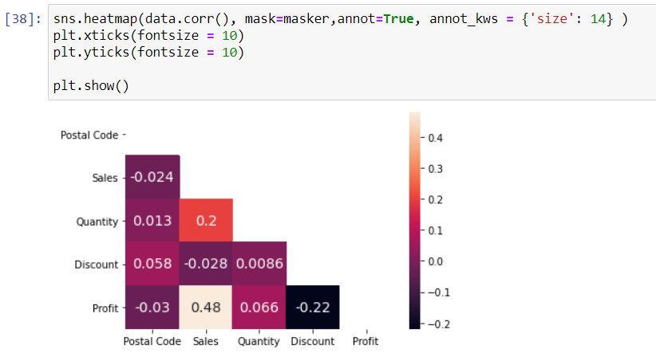

```python
from IPython.display import Image
Image(filename="C:\\Users\\SKR\\Edubridge\\heatmap sample.PNG")
```

### Heatmap

Heatmap provides realtime analytics to help chief editors and marketeers understand in seconds which are their best performing contents and which are less attractive to users.

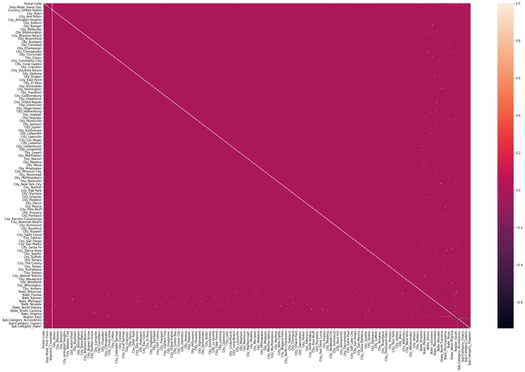

```python
plt.figure(figsize =(32,20))
sns.heatmap(data.corr())
plt.show()
```

[figure not shown]

```python
plt.figure(figsize =(34,21))

sns.heatmap(data.corr(), mask=masker,annot=True )
plt.xticks(fontsize = 10)
plt.yticks(fontsize = 10)
plt.show()
```

[figure not shown]

```python
plt.figure(figsize =(34,21))

sns.heatmap(data.corr(), mask=masker,annot=True, annot_kws = {'size': 14} )
plt.xticks(fontsize = 10)
plt.yticks(fontsize = 10)

plt.show()
```

```python
sal_prof_corr = round(data['Sales'].corr(data['Profit']),3)
```

```python
sal_prof_corr
```

```
0.479
```

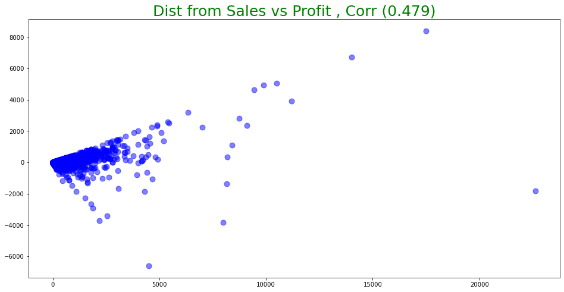

```python
plt.figure(figsize = (16, 8))
plt.title (f'Dist from Sales vs Profit , Corr ({sal_prof_corr})',
                       fontsize = 25, color = 'green')
plt.scatter(x=data['Sales'], y =data['Profit'], alpha = 0.5, color = 'blue', s= 80)


plt.show()
```

### Correlation

Correlation is a statistical measure that indicates the extent to which two or more variables fluctuate in relation to each other.

# −1.0≤ρxy≤+1.0

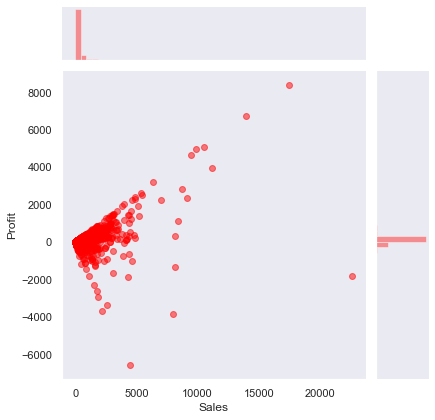

```python
sns.set()
sns.set_style('dark')
sns.jointplot(x=data['Sales'], y =data['Profit'], color = 'red', joint_kws = {'alpha' : 0.5},)


plt.show()
```

### Joint plot:

The joint plot shows bi variant scatter plot and uni variate histogram in the same plot .

we will use seaborn library to create a joint plot

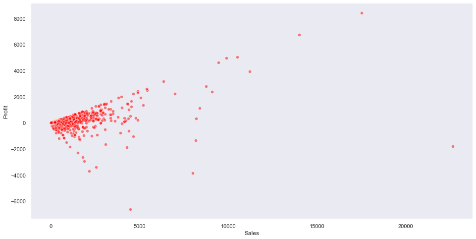

```python
sns.set()
sns.set_style('dark')

plt.figure(figsize = (16, 8))
sns.scatterplot(x=data['Sales'], y =data['Profit'], color = 'red', alpha = 0.5)


plt.show()
```

### scatter plot

A scatter plot uses dots to represent values for two different numeric variables

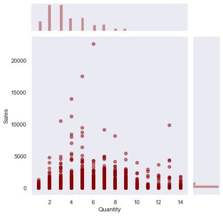

```python
# Quantity  vs Sales
sns.set() # to reset any previous styling
sns.set_style('dark')# to set style.
sns.jointplot(x=data['Quantity'], y =data['Sales'], color = 'darkred', joint_kws = {'alpha' : 0.5} ) # jointplot gives  scatter plot
plt.show()
```

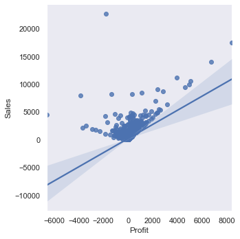

```python
# plotting the regressioin line using sns lmplot
sns.lmplot(x ='Profit', y = 'Sales', data = data)
plt.show()
```

### lmplot:

```
seaborn.lmplot() method is used to draw a scatter plot onto a FacetGrid.
```

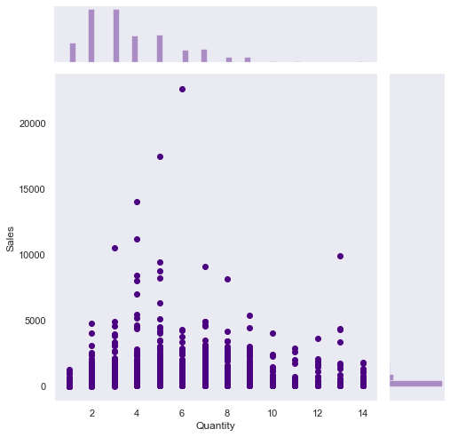

```python
sns.set() # to reset any previous styling
sns.set_style('dark')# to set style.
# height  = 7 is optional
sns.jointplot(x=data['Quantity'], y =data['Sales'], color = 'indigo', kind = 'scatter', height = 7) # jointplot gives scatter plot
plt.show()
```

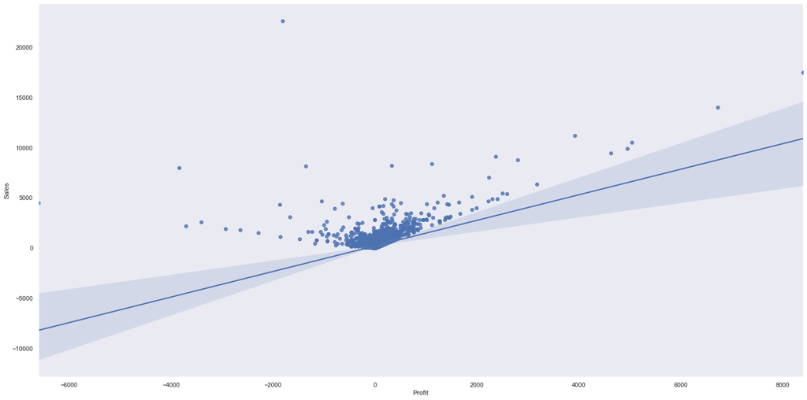

```python
# All defaults regressions with lmplot......
# height = 10 is optional
sns.lmplot(x ='Profit', y = 'Sales', data = data, height =10, aspect = 2)
plt.show()
```

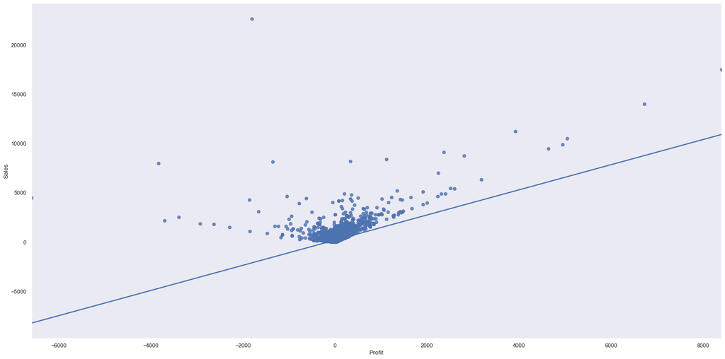

```python
# without the confidence interval that is ci = None
sns.lmplot(x ='Profit', y = 'Sales', data = data, height =10, aspect = 2, ci = None )
plt.show()
```

```python
sns.pairplot(data , kind = 'reg')
plt.show()
```

[output not shown]

```python
y_log = np.log(data['Sales'])
```

```python
y_log.head()
```

```
0    5.568192
1    6.595699
2    2.682390
3    6.864407
4    3.107631
Name: Sales, dtype: float64
```

```python
y_log.tail()
```

```
9989    3.228747
9990    4.521354
9991    5.555190
9992    3.387774
9993    5.493720
Name: Sales, dtype: float64
```

```python
y_log.skew()
```

```
0.18864805793321923
```

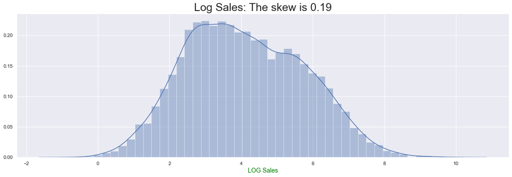

```python
# plotting the histogram and the distribution, after log transformation
sns.set()
plt.figure(figsize=(20,6))
sns.distplot(y_log)

plt.title(f'Log Sales: The skew is {round(y_log.skew(),2)}', fontsize = 25)# note the f string used to print the y_log.skew()
plt.xlabel('LOG Sales', fontsize =14, color = 'green' )
plt.show()
```

```python
from sklearn.model_selection import train_test_split
from sklearn.linear_model import LinearRegression
import statsmodels.api as sm
from sklearn.metrics import r2_score,mean_squared_error
```

```python
import warnings
warnings.simplefilter('ignore')
```

```python
# Multivariable regression
prices = data['Sales']
features = data.drop('Sales', axis =1)
X_train, X_test, y_train, y_test = train_test_split(features, prices, test_size = 0.2 , random_state=10)
```

```python
X_train
```

|  | Postal Code | Quantity | Discount | Profit | Ship Mode_First Class | Ship Mode_Same Day | Ship Mode_Second Class | Ship Mode_Standard Class | Segment_Consumer | Segment_Corporate | ... | Sub-Category_Envelopes | Sub-Category_Fasteners | Sub-Category_Furnishings | Sub-Category_Labels | Sub-Category_Machines | Sub-Category_Paper | Sub-Category_Phones | Sub-Category_Storage | Sub-Category_Supplies | Sub-Category_Tables |
| --- | --- | --- | --- | --- | --- | --- | --- | --- | --- | --- | --- | --- | --- | --- | --- | --- | --- | --- | --- | --- | --- |
| 7491 | 13501 | 6 | 0.0 | 5.9970 | 0 | 1 | 0 | 0 | 1 | 0 | ... | 0 | 0 | 0 | 0 | 0 | 0 | 1 | 0 | 0 | 0 |
| 6640 | 46203 | 6 | 0.0 | 60.4224 | 0 | 0 | 0 | 1 | 1 | 0 | ... | 0 | 0 | 0 | 0 | 0 | 0 | 0 | 0 | 0 | 0 |
| 9242 | 94122 | 6 | 0.2 | 4.6488 | 0 | 0 | 0 | 1 | 0 | 0 | ... | 0 | 0 | 0 | 0 | 0 | 0 | 0 | 0 | 0 | 0 |
| 2468 | 23602 | 5 | 0.0 | 15.5520 | 0 | 0 | 0 | 1 | 1 | 0 | ... | 0 | 0 | 0 | 0 | 0 | 1 | 0 | 0 | 0 | 0 |
| 3135 | 75081 | 3 | 0.2 | -15.5904 | 0 | 0 | 0 | 1 | 0 | 0 | ... | 0 | 0 | 0 | 0 | 0 | 0 | 0 | 1 | 0 | 0 |
| ... | ... | ... | ... | ... | ... | ... | ... | ... | ... | ... | ... | ... | ... | ... | ... | ... | ... | ... | ... | ... | ... |
| 9372 | 43229 | 5 | 0.2 | 2.9145 | 1 | 0 | 0 | 0 | 0 | 1 | ... | 0 | 1 | 0 | 0 | 0 | 0 | 0 | 0 | 0 | 0 |
| 7291 | 94122 | 9 | 0.0 | 12.2247 | 1 | 0 | 0 | 0 | 1 | 0 | ... | 0 | 0 | 0 | 1 | 0 | 0 | 0 | 0 | 0 | 0 |
| 1344 | 11520 | 5 | 0.0 | 6.0030 | 0 | 0 | 0 | 1 | 1 | 0 | ... | 0 | 0 | 0 | 1 | 0 | 0 | 0 | 0 | 0 | 0 |
| 7293 | 90036 | 7 | 0.0 | 21.5964 | 0 | 0 | 0 | 1 | 1 | 0 | ... | 0 | 0 | 1 | 0 | 0 | 0 | 0 | 0 | 0 | 0 |
| 1289 | 10009 | 3 | 0.0 | 7.4952 | 0 | 0 | 0 | 1 | 0 | 1 | ... | 0 | 0 | 0 | 0 | 0 | 0 | 0 | 0 | 0 | 0 |

7995 rows × 616 columns

```python
y_train
```

```
7491    119.940
6640    125.880
9242     14.304
2468     32.400
3135     77.952
         ...
9372      8.040
7291     26.010
1344     13.050
7293     59.990
1289     20.820
Name: Sales, Length: 7995, dtype: float64
```

```python
X_test
```

|  | Postal Code | Quantity | Discount | Profit | Ship Mode_First Class | Ship Mode_Same Day | Ship Mode_Second Class | Ship Mode_Standard Class | Segment_Consumer | Segment_Corporate | ... | Sub-Category_Envelopes | Sub-Category_Fasteners | Sub-Category_Furnishings | Sub-Category_Labels | Sub-Category_Machines | Sub-Category_Paper | Sub-Category_Phones | Sub-Category_Storage | Sub-Category_Supplies | Sub-Category_Tables |
| --- | --- | --- | --- | --- | --- | --- | --- | --- | --- | --- | --- | --- | --- | --- | --- | --- | --- | --- | --- | --- | --- |
| 937 | 87401 | 1 | 0.0 | 54.3966 | 1 | 0 | 0 | 0 | 0 | 1 | ... | 0 | 0 | 0 | 0 | 0 | 0 | 0 | 0 | 0 | 0 |
| 4514 | 23666 | 1 | 0.0 | 75.6548 | 0 | 0 | 1 | 0 | 1 | 0 | ... | 0 | 0 | 0 | 0 | 0 | 0 | 0 | 0 | 0 | 0 |
| 3648 | 38109 | 2 | 0.7 | -2.0622 | 0 | 0 | 0 | 1 | 1 | 0 | ... | 0 | 0 | 0 | 0 | 0 | 0 | 0 | 0 | 0 | 0 |
| 192 | 10035 | 3 | 0.2 | 46.9764 | 1 | 0 | 0 | 0 | 0 | 0 | ... | 0 | 0 | 0 | 0 | 0 | 0 | 0 | 0 | 0 | 0 |
| 8073 | 77340 | 5 | 0.8 | -9.7050 | 0 | 0 | 0 | 1 | 1 | 0 | ... | 0 | 0 | 0 | 0 | 0 | 0 | 0 | 0 | 0 | 0 |
| ... | ... | ... | ... | ... | ... | ... | ... | ... | ... | ... | ... | ... | ... | ... | ... | ... | ... | ... | ... | ... | ... |
| 6550 | 10035 | 4 | 0.1 | 21.8376 | 0 | 0 | 1 | 0 | 1 | 0 | ... | 0 | 0 | 0 | 0 | 0 | 0 | 0 | 0 | 0 | 0 |
| 9278 | 19140 | 7 | 0.7 | -5.6007 | 0 | 0 | 0 | 1 | 1 | 0 | ... | 0 | 0 | 0 | 0 | 0 | 0 | 0 | 0 | 0 | 0 |
| 987 | 77041 | 2 | 0.8 | -1.8904 | 0 | 1 | 0 | 0 | 1 | 0 | ... | 0 | 0 | 0 | 0 | 0 | 0 | 0 | 0 | 0 | 0 |
| 6148 | 94109 | 2 | 0.2 | 12.5990 | 0 | 0 | 1 | 0 | 1 | 0 | ... | 0 | 0 | 0 | 0 | 0 | 0 | 1 | 0 | 0 | 0 |
| 2677 | 81001 | 7 | 0.7 | -8.1312 | 0 | 1 | 0 | 0 | 1 | 0 | ... | 0 | 0 | 0 | 0 | 0 | 0 | 0 | 0 | 0 | 0 |

1999 rows × 616 columns

```python
y_test
```

```
937     159.990
4514    290.980
3648      2.946
192     626.352
8073      6.470
         ...
6550    327.564
9278      8.001
987       1.112
6148    201.584
2677     11.088
Name: Sales, Length: 1999, dtype: float64
```

```python
# check the amount of data in Training...

len(X_train)/len(features)
```

```
0.7999799879927957
```

```python
regression = LinearRegression()
regression.fit(X_train,y_train)
```

```
LinearRegression()
```

```python
pd.DataFrame(data=regression.coef_, index=X_train.columns, columns=['coef'])
```

|  | coef |
| --- | --- |
| Postal Code | -0.019625 |
| Quantity | 46.170279 |
| Discount | 151.728088 |
| Profit | 1.422263 |
| Ship Mode_First Class | -12.250641 |
| ... | ... |
| Sub-Category_Paper | -93.562890 |
| Sub-Category_Phones | -355.778642 |
| Sub-Category_Storage | 109.663338 |
| Sub-Category_Supplies | 169.036299 |
| Sub-Category_Tables | 260.826374 |

616 rows × 1 columns

```python
print('Intercept', regression.intercept_)
```

```
Intercept 1162.299969864467
```

```python
print('Training data r-squared:', regression.score(X_train, y_train))
```

```
Training data r-squared: 0.5395733078599285
```

```python
# working with the test data....

print('Test data r-squared:', regression.score(X_test, y_test))
```

```
Test data r-squared: 0.17664260933911857
```

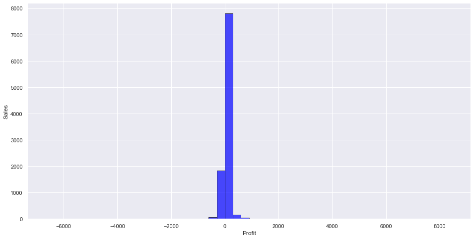

```python
plt.figure(figsize= (16,8))
plt.hist(data['Profit'], bins =50, ec = 'black', color = 'blue', alpha = 0.7)# bins 50...setting color by  hexcode
plt.xlabel('Profit')
plt.ylabel('Sales')
plt.show()
```

```python
# Measuring the skew!!!
data['Sales'].skew()
```

```
12.97275234181623
```

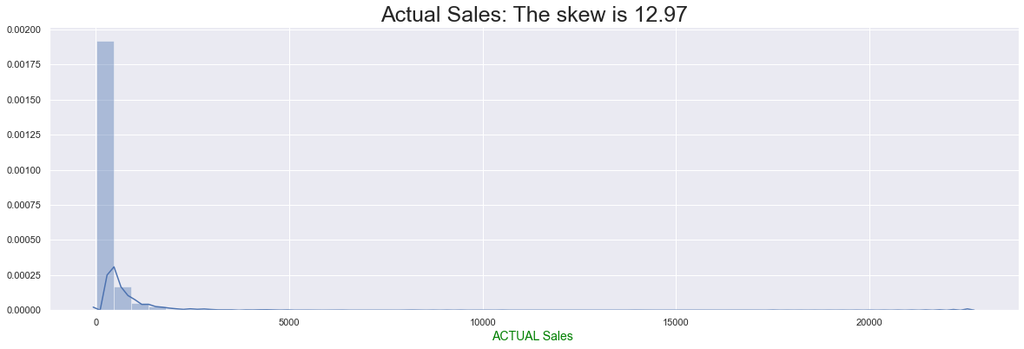

```python
#plot before log transformation for comparison
skew=round(data['Sales'].skew(),2)
sns.set()
plt.figure(figsize=(20,6))
sns.distplot(data['Sales'])
plt.title(f'Actual Sales: The skew is {skew}', fontsize = 25)
plt.xlabel( 'ACTUAL Sales ', fontsize =14, color = 'green' )
plt.show()
```

```python
regression_pred = regression.predict(X_test)
print('r2-score:',r2_score(y_test,regression_pred))
print('RMSE:',np.sqrt(mean_squared_error(y_test,regression_pred)))
```

```
r2-score: 0.17664260933911857
RMSE: 725.6301791206708
```

```python
transformed_data = features # new data frame
transformed_data['LOG_Sales'] = y_log # added the log sales to the new data frame called transformed data
transformed_data
```

|  | Postal Code | Quantity | Discount | Profit | Ship Mode_First Class | Ship Mode_Same Day | Ship Mode_Second Class | Ship Mode_Standard Class | Segment_Consumer | Segment_Corporate | ... | Sub-Category_Fasteners | Sub-Category_Furnishings | Sub-Category_Labels | Sub-Category_Machines | Sub-Category_Paper | Sub-Category_Phones | Sub-Category_Storage | Sub-Category_Supplies | Sub-Category_Tables | LOG_Sales |
| --- | --- | --- | --- | --- | --- | --- | --- | --- | --- | --- | --- | --- | --- | --- | --- | --- | --- | --- | --- | --- | --- |
| 0 | 42420 | 2 | 0.00 | 41.9136 | 0 | 0 | 1 | 0 | 1 | 0 | ... | 0 | 0 | 0 | 0 | 0 | 0 | 0 | 0 | 0 | 5.568192 |
| 1 | 42420 | 3 | 0.00 | 219.5820 | 0 | 0 | 1 | 0 | 1 | 0 | ... | 0 | 0 | 0 | 0 | 0 | 0 | 0 | 0 | 0 | 6.595699 |
| 2 | 90036 | 2 | 0.00 | 6.8714 | 0 | 0 | 1 | 0 | 0 | 1 | ... | 0 | 0 | 1 | 0 | 0 | 0 | 0 | 0 | 0 | 2.682390 |
| 3 | 33311 | 5 | 0.45 | -383.0310 | 0 | 0 | 0 | 1 | 1 | 0 | ... | 0 | 0 | 0 | 0 | 0 | 0 | 0 | 0 | 1 | 6.864407 |
| 4 | 33311 | 2 | 0.20 | 2.5164 | 0 | 0 | 0 | 1 | 1 | 0 | ... | 0 | 0 | 0 | 0 | 0 | 0 | 1 | 0 | 0 | 3.107631 |
| ... | ... | ... | ... | ... | ... | ... | ... | ... | ... | ... | ... | ... | ... | ... | ... | ... | ... | ... | ... | ... | ... |
| 9989 | 33180 | 3 | 0.20 | 4.1028 | 0 | 0 | 1 | 0 | 1 | 0 | ... | 0 | 1 | 0 | 0 | 0 | 0 | 0 | 0 | 0 | 3.228747 |
| 9990 | 92627 | 2 | 0.00 | 15.6332 | 0 | 0 | 0 | 1 | 1 | 0 | ... | 0 | 1 | 0 | 0 | 0 | 0 | 0 | 0 | 0 | 4.521354 |
| 9991 | 92627 | 2 | 0.20 | 19.3932 | 0 | 0 | 0 | 1 | 1 | 0 | ... | 0 | 0 | 0 | 0 | 0 | 1 | 0 | 0 | 0 | 5.555190 |
| 9992 | 92627 | 4 | 0.00 | 13.3200 | 0 | 0 | 0 | 1 | 1 | 0 | ... | 0 | 0 | 0 | 0 | 1 | 0 | 0 | 0 | 0 | 3.387774 |
| 9993 | 92683 | 2 | 0.00 | 72.9480 | 0 | 0 | 1 | 0 | 1 | 0 | ... | 0 | 0 | 0 | 0 | 0 | 0 | 0 | 0 | 0 | 5.493720 |

9994 rows × 617 columns

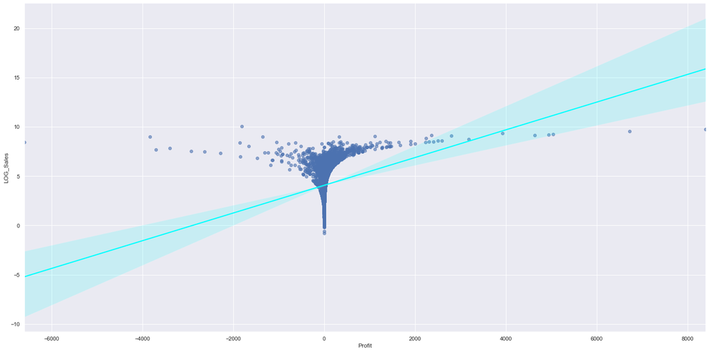

```python
sns.lmplot(x='Profit', y='LOG_Sales', data=transformed_data, height =10,aspect = 2,
           scatter_kws={'alpha': 0.6}, line_kws={'color':'cyan'})
plt.show()
```

```python
prices = np.log(data['Sales']) # Use log sales
features = data.drop('Sales', axis=1)

X_train, X_test, y_train, y_test = train_test_split(features, prices,
                                                    test_size=0.2, random_state=10)

regr = LinearRegression()
regr.fit(X_train, y_train)

print('Training data r-squared:', regr.score(X_train, y_train))
print('Test data r-squared:', regr.score(X_test, y_test))


pd.DataFrame(data=regr.coef_, index=X_train.columns, columns=['coef'])
```

```
Training data r-squared: 0.6182020584213566
Test data r-squared: 0.5473020484526968
```

|  | coef |
| --- | --- |
| Postal Code | 0.000073 |
| Quantity | 0.240288 |
| Discount | -1.747910 |
| Profit | 0.000905 |
| Ship Mode_First Class | -0.023505 |
| ... | ... |
| Sub-Category_Paper | -0.203985 |
| Sub-Category_Phones | -0.344193 |
| Sub-Category_Storage | 1.135869 |
| Sub-Category_Supplies | 0.008036 |
| Sub-Category_Tables | 0.973109 |

616 rows × 1 columns

#### Regression before transformation

Training data r-squared: 0.5395733078599285..........., Test data r-squared: 0.17664260933911857

##### Regression with log

Training data r-squared: 0.6182020584213566......... Test data r-squared: 0.5473020484526968